# (Ford Go bike Trip durations and how it is affected by other attributes)

## by (Omar Aref)

## Investigation Overview

> Describe the distribution of trip durations and investigate the variables that affect them.

## Dataset Overview

> Data set consists of 180K+ records with 22 columns represnting the duration , data , station , gender and customer type.

# Have you ever wondered what makes a Bike trip duration long? answering this question can help us better allocate bikes in stations.

## (Visualization 1)

> Here we can start by plotting the distribution of minutes to start our investigation.

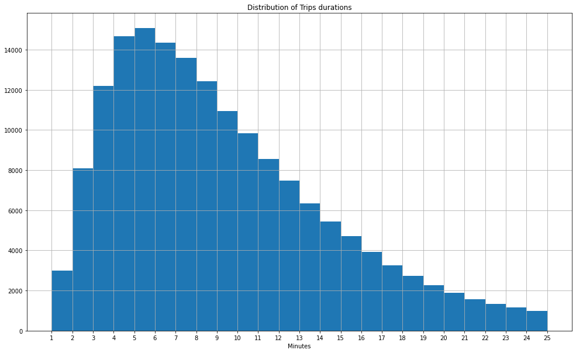

```python
bins = np.arange(1 , 26 , 1 );
plt.figure(figsize=(16.7,10))
plt.hist(data = df , x = 'duration_min' , bins = bins );
plt.xticks(bins);
plt.grid()
plt.title('Distribution of Trips durations')
plt.xlabel('Minutes');
```

## (Visualization 2)

> Does the day affects how the duration of the trip ? **We will start with the Duration against the Start day:**

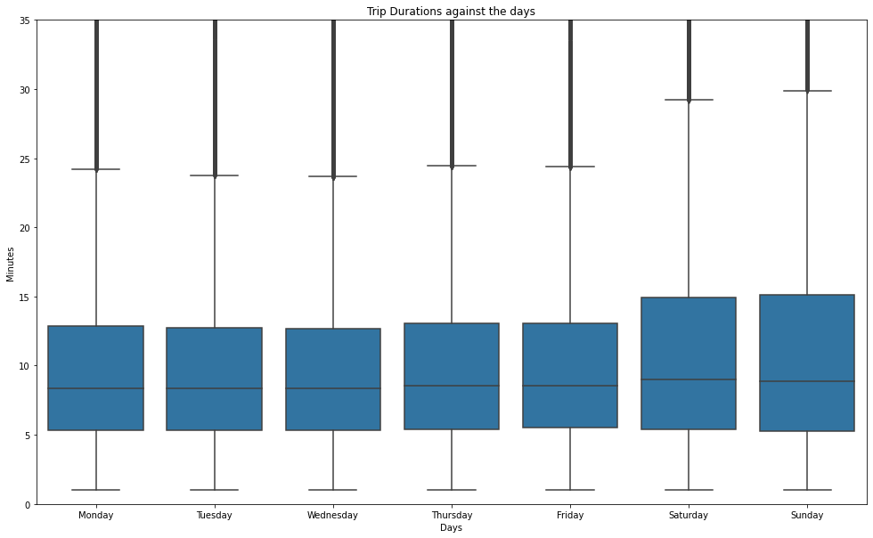

```python
base_color = sb.color_palette()[0]
bins = ['Monday' , 'Tuesday' , 'Wednesday' , 'Thursday' , 'Friday' , 'Saturday' , 'Sunday']
plt.figure(figsize=(16.7,10))
sb.boxplot(data = df , x = 'start_day'  , y = 'duration_min' , color= base_color);
plt.title('Trip Durations against the days')
plt.xlabel('Days')
plt.ylabel('Minutes')
plt.xticks([0,1,2,3,4,5,6,] ,bins);
plt.ylim(0,35);
```

Here we observe that the average of duration in the weekends is higher than weekdays. which makes it one of the contributing factors on the trips duration

## (Visualization 3)

> We can see how the birth year of the users affect the duration (do younger people have longer rides ?), we will ignore the bar in 2001 since it is an outlier

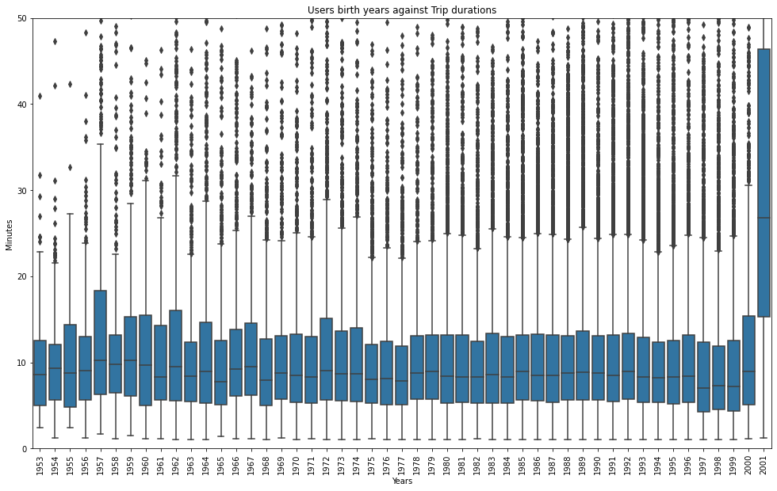

```python
plt.figure(figsize=(16.7,10))
birthYears = df['member_birth_year'].value_counts()
order_index = np.sort(birthYears.index)

plt.ylim(0,50)
sb.boxplot(data = df , x = 'member_birth_year'  , y = 'duration_min' , color= base_color , order=order_index[26:] );
plt.xticks(rotation = 90);
plt.title('Users birth years against Trip durations')
plt.xlabel('Years');
plt.ylabel('Minutes');
```

## (Visualization 4)

> Does the gender and the user type affect the duration of the trips ?  
> Now we will explore the duration against the user type and the gender

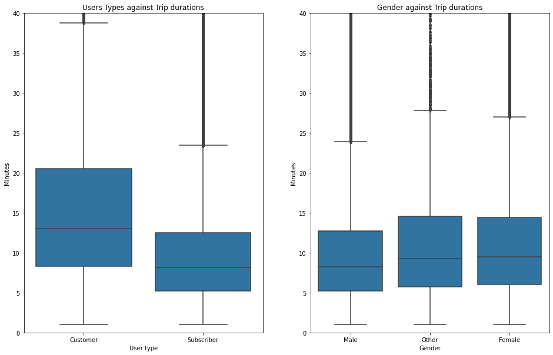

```python
plt.figure(figsize=(16,10))
plt.subplot(1,2,1)
sb.boxplot(data = df , x = 'user_type'  , y = 'duration_min' , color= base_color);
plt.title('Users Types against Trip durations')
plt.xlabel('User type');
plt.ylabel('Minutes');
plt.ylim(0,40)
plt.subplot(1,2,2)
sb.boxplot(data = df , x = 'member_gender'  , y = 'duration_min' , color= base_color);
plt.title('Gender against Trip durations')
plt.xlabel('Gender');
plt.ylabel('Minutes');
plt.ylim(0,40);
```

Here We have 2 observations:  
1) Customers have a higher average duration time compared to the Subscriber. which makes it the second contribouting factor to the trip duration  
2) Female & other gender have a higher average trip duration than males.however they are not that significant

## (Visualization 5)

> Last thing we see the distribution of stations on the map by plotting the co-ordinates of the points, we can see they are distibuted in clusters.

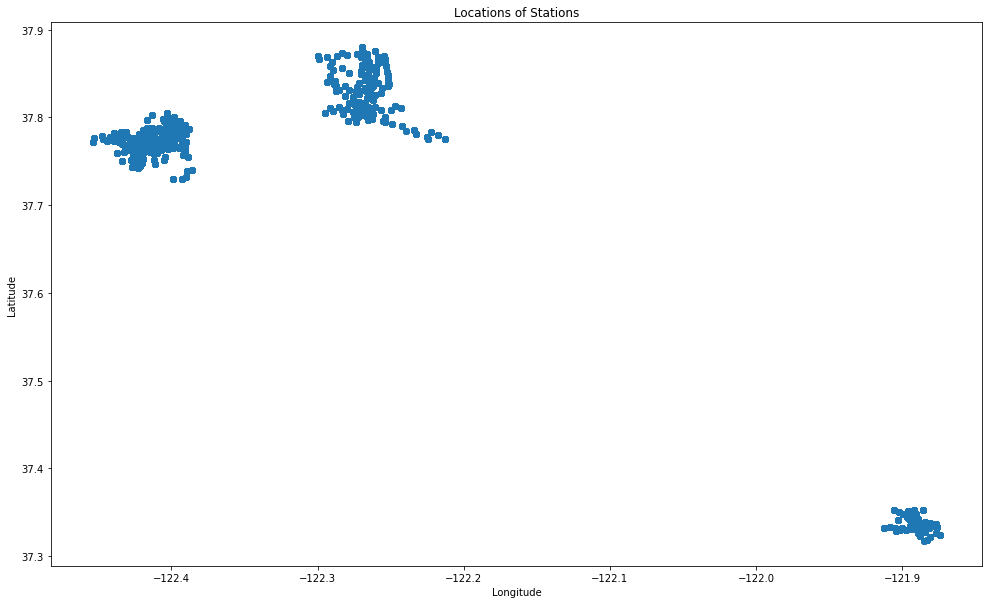

```python
plt.figure(figsize=(16.7,10))
plt.scatter(data =df , y = 'start_station_latitude' , x = 'start_station_longitude' );
plt.title('Locations of Stations')
plt.xlabel('Longitude');
plt.ylabel('Latitude');
```

## (Visualization 6)

> We can then dive into the bivariate plot. We will use the start cluster column. Does the cluster have an effect on the duration ?

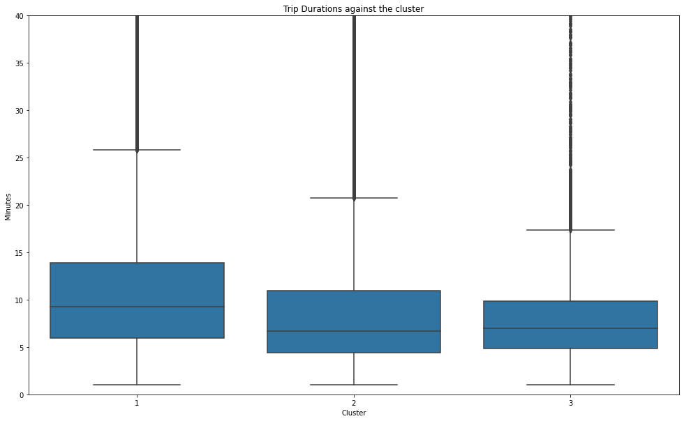

```python
plt.figure(figsize=(16.7,10))
sb.boxplot(data = df , x = 'start_cluster' , y = 'duration_min' ,  color= base_color )
plt.ylim(0,40);
plt.title('Trip Durations against the cluster')
plt.xlabel('Cluster');
plt.ylabel('Minutes');
```

Here we can see that trips starting from cluster 1 have a higher average trips durationt than cluster 2 and cluster 3

## (Visualization 7)

> We will start by building up on the Cluster and station Locations and add the duration.  
> Do certain starting stations for trips have longer trip durations on average or not ?

```python
group = df.groupby('start_station_name' ).mean().reset_index()
```

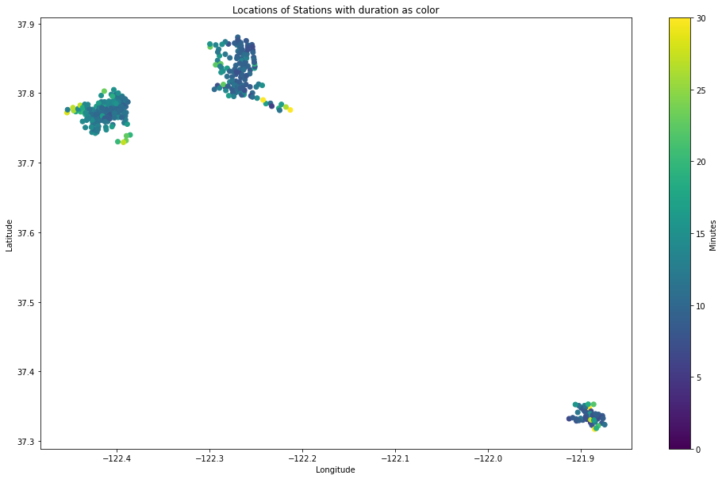

```python
plt.figure(figsize=(16.7,10))
plt.scatter(data = group, y = 'start_station_latitude', x = 'start_station_longitude', c = 'duration_min')
plt.title('Locations of Stations with duration as color')
plt.xlabel('Longitude');
plt.ylabel('Latitude');
plt.colorbar(label = 'Minutes');
plt.clim(0,30)
```

> **Very Interisting Finding**:  
> Looking at the station points and how are they plotted we they represent the locations of the stations on a map we can see that the trips with a higher duration tend to be on the edges rather than the center, we can then zoom on each cluster.

## (Visualization 8)

> We zoom in on each cluster and we see that the farther away stations from the center the longer the trip is.

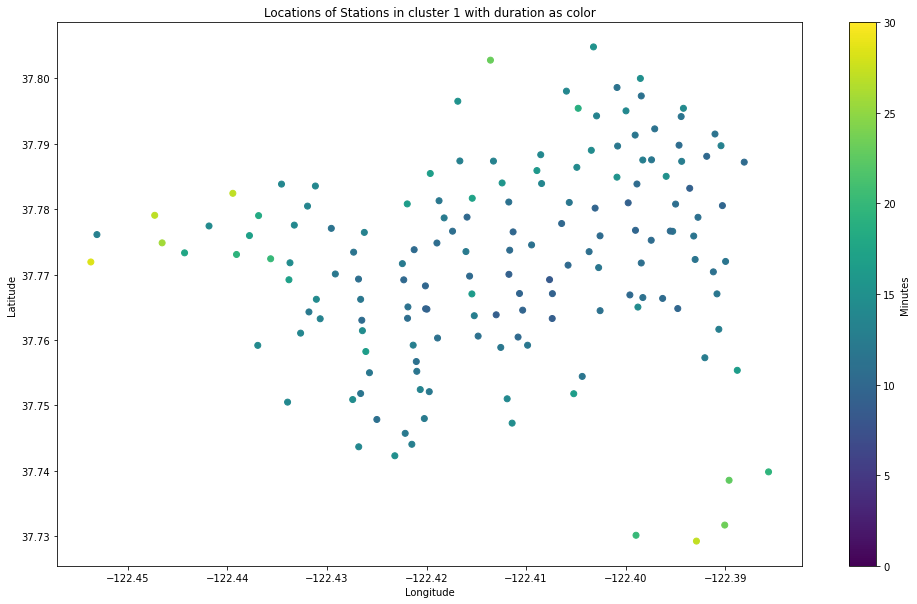

```python
df1 = group.query('start_cluster ==1' )
plt.figure(figsize=(16.7,10))
plt.scatter(data = df1, y = 'start_station_latitude', x = 'start_station_longitude', c = 'duration_min' , cmap = 'viridis')
plt.title('Locations of Stations in cluster 1 with duration as color')
plt.xlabel('Longitude');
plt.ylabel('Latitude');
plt.colorbar(label = 'Minutes');

plt.clim(0,30)
```

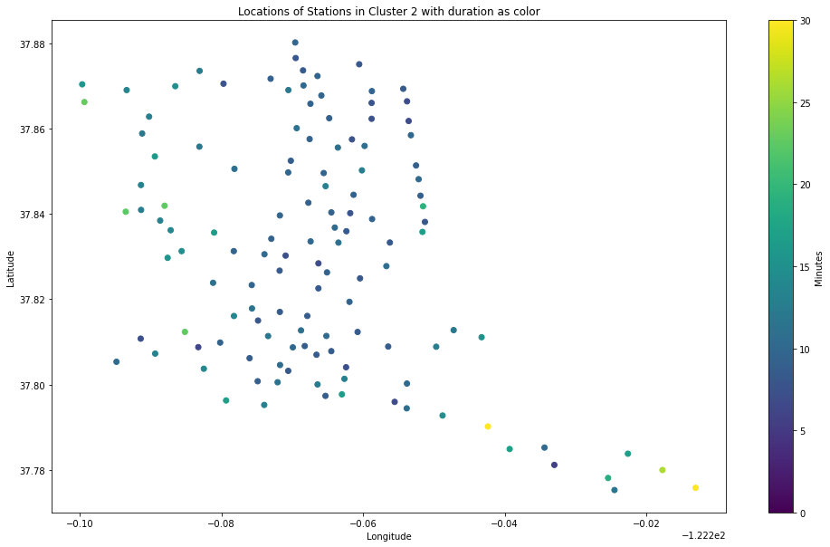

```python
df1 = group.query('start_cluster ==2' )
plt.figure(figsize=(16.7,10))
plt.scatter(data = df1, y = 'start_station_latitude', x = 'start_station_longitude', c = 'duration_min')
plt.title('Locations of Stations in Cluster 2 with duration as color')
plt.xlabel('Longitude');
plt.ylabel('Latitude');
plt.colorbar(label = 'Minutes');
plt.clim(0,30)
```

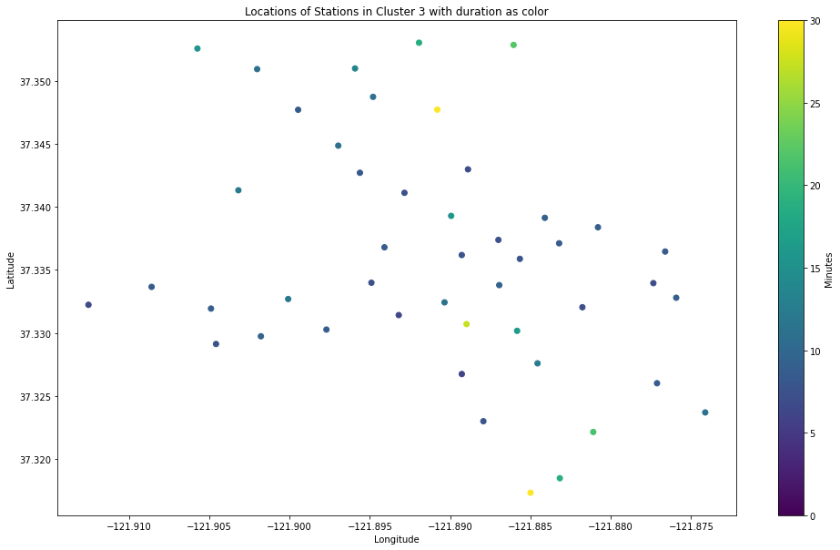

```python
df1 = group.query('start_cluster ==3' )
plt.figure(figsize=(16.7,10))
plt.scatter(data = df1, y = 'start_station_latitude', x = 'start_station_longitude', c = 'duration_min')
plt.title('Locations of Stations in Cluster 3 with duration as color')
plt.xlabel('Longitude');
plt.ylabel('Latitude');
plt.colorbar(label = 'Minutes');
plt.clim(0,30)
```